# Regresión Lineal Múltiple

Miguel Ángel Sánchez Guachamín

2 de agosto de 2015

### Introducción

Dado varias variables, se pretende realizar una regresión lineal multiple con las variables que influyan mas en la regresión.

### Procedimiento

Comenzamos cargando los archivos **poblacion1.xlsx** y **poblacion2.xlsx**, y analizamos sus dimensiones.

```r
library(readxl)
poblacion1 <- read_excel("poblacion1.xlsx", sheet=1, na=" ")
poblacion2 <- read_excel("poblacion2.xlsx", sheet=1, na=" ")
dim1<-dim(poblacion1)
dim2<-dim(poblacion2)
```

Analizando la información disponemos de 44 observaciones de 4 variables para **poblacion1.xlsx**. Y de 40 observaciones de 7 variables para **poblacion2.xlsx**.

Luego, unimos los dos archivos en un mismo objeto el cual lamamos **poblacion**.

```r
poblacion<-merge(poblacion1, poblacion2, by="identificador",suffixes=c("",""))
View (poblacion)
```

y realizamos digramas de cajas para las variables continuas y diagramas de barras para las variables discretas.

```
## [1] "poblacion"
```

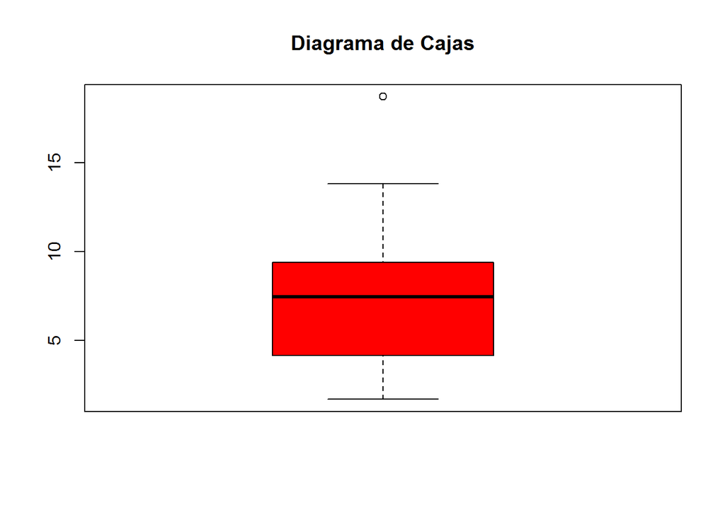

```
## [1] "var.pobl.mayor"
```

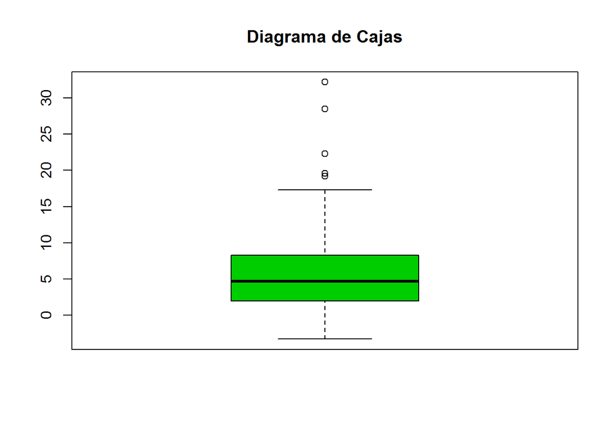

```
## [1] "menores.18"
```

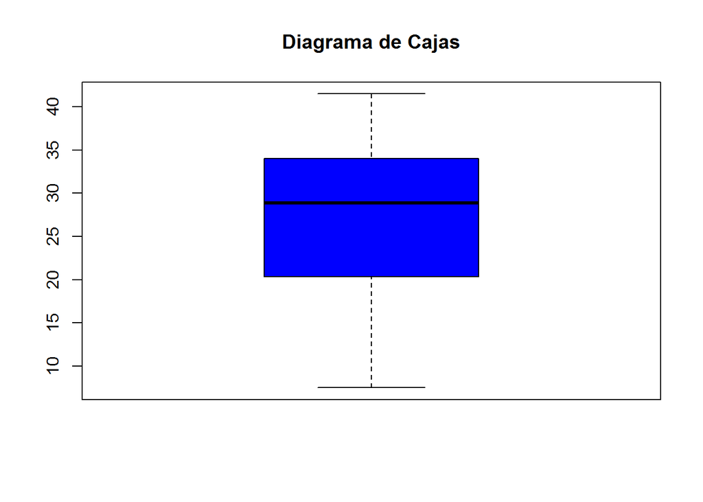

```
## [1] "part.almz.escl"
```

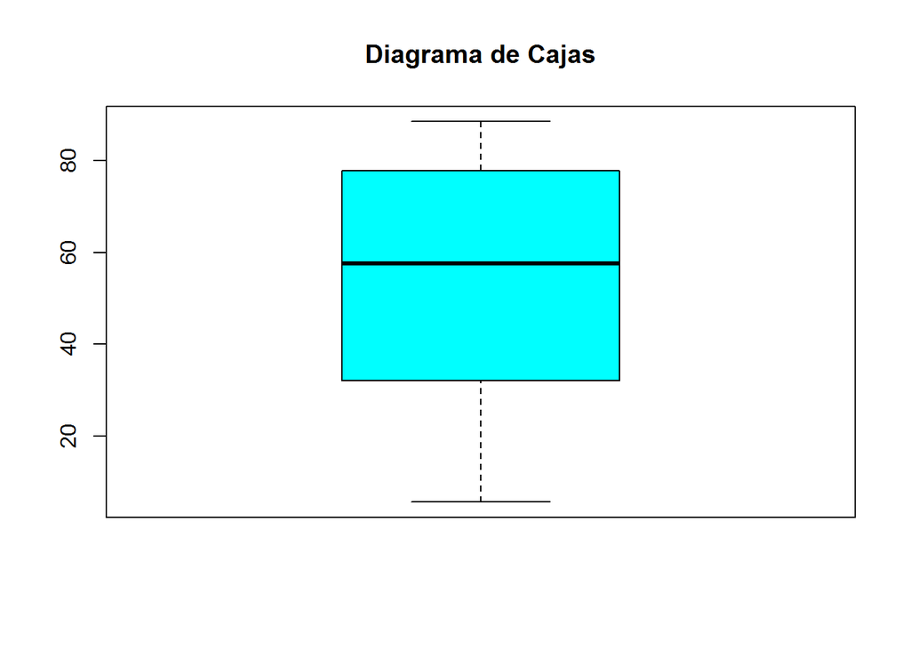

```
## [1] "var.ingresos"
```

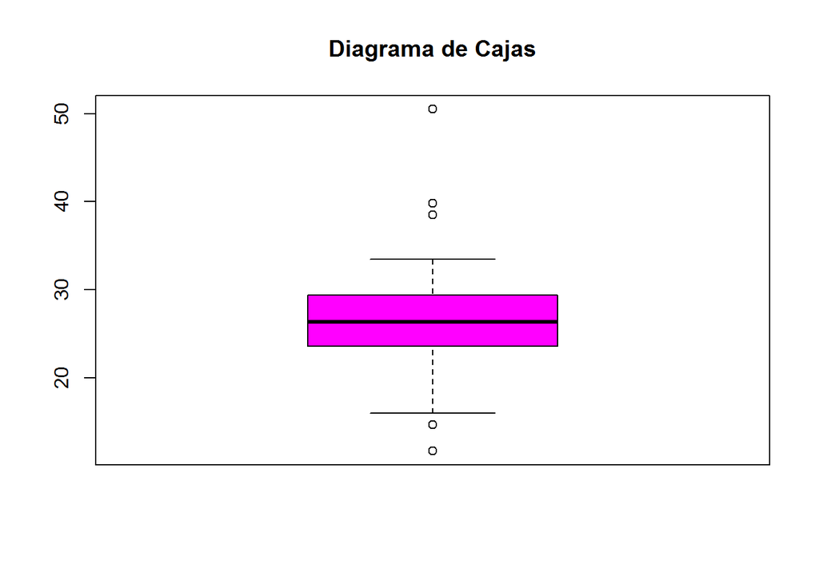

```
## [1] "tasa.crimen"
```

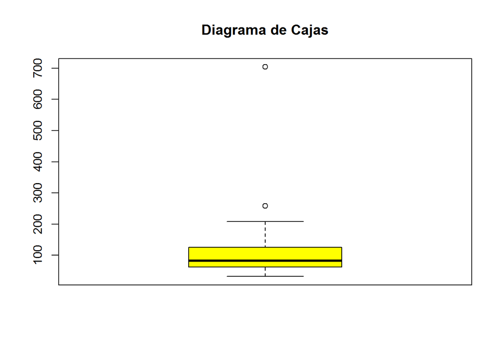

```
## [1] "var.tasa.crimen"
```

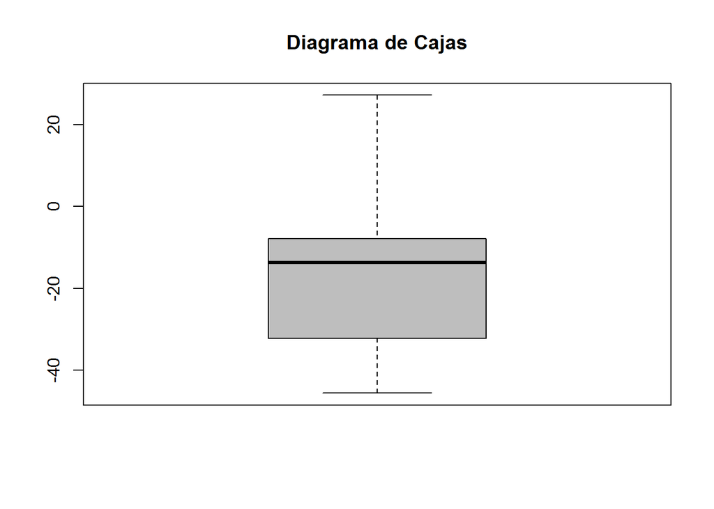

```
## [1] "region"
```

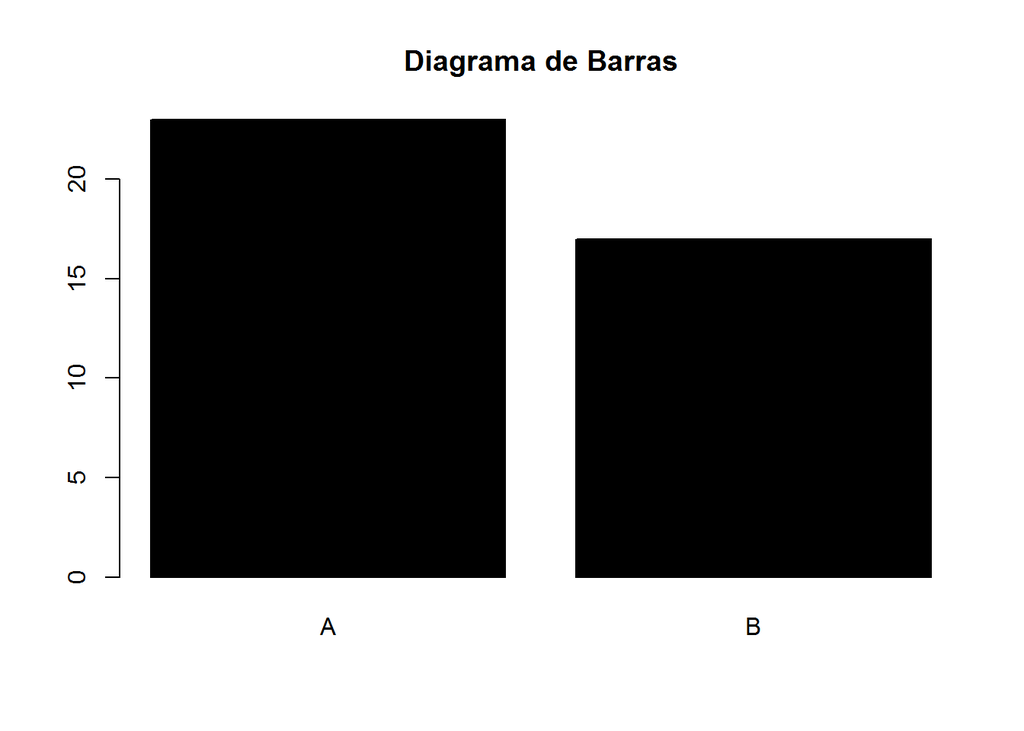

```
## [1] "serv.bas.compl"
```

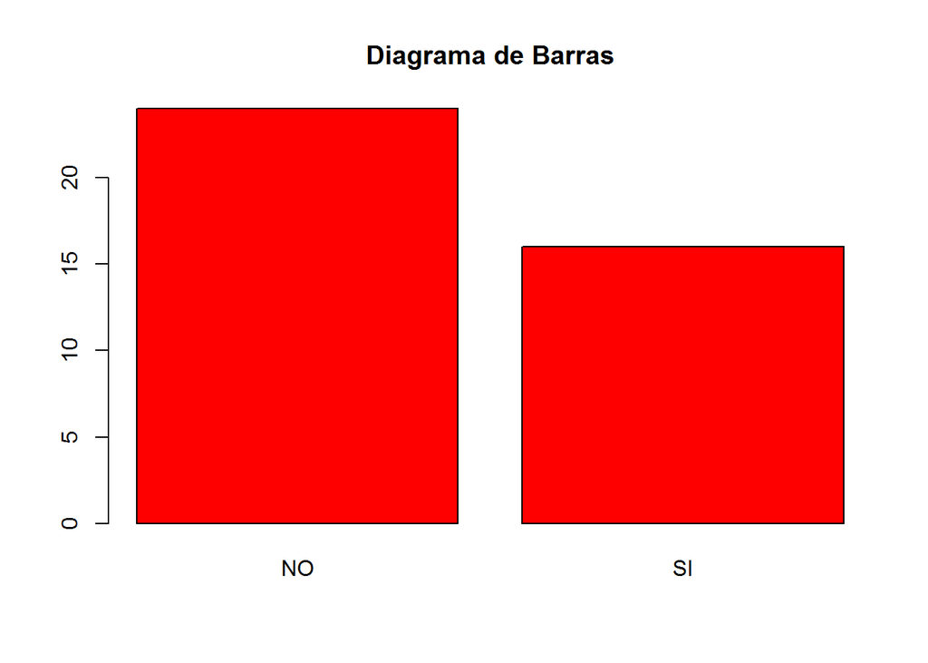

```r
for(j in 2:dim(poblacion)[2]){
  if(is.numeric(poblacion[,j])==TRUE){
    print(names(poblacion)[j])
    boxplot(poblacion[,j], main = "Diagrama de Cajas" , col = j)
  }else {
    print(names(poblacion)[j])
    barplot(table(poblacion[,j]), col = j, main = "Diagrama de Barras")
  }
}
```

```r
#Calculamos el mínimo, media, máximo, desviación estandar, primer cuartil de cada variable numérica y la frecuencia en el caso de variables discretas.
  for(j in 2:dim(poblacion)[2]){
    if(is.numeric(poblacion[,j])==TRUE){

      print(names(poblacion)[j])
      print("minimo=")
      print(min(poblacion[,j]))
      print("media=")
      print(mean(poblacion[,j]))
      print("maximo=")
      print(max(poblacion[,j]))
      print("desviacion estandar=")
      print(sd(poblacion[,j]))
      print("cuartiles=")
      print(quantile(poblacion[,j],probs=seq(0,1,0.25),na.rm = FALSE))
    }else {

      print(names(poblacion)[j])
      print("frecuencia")
      print(table(poblacion[,j])/dim(poblacion)[1])

    }

  }
```

[output not shown]

Calculamos la correlación que existe entre la variable dependiente **poblacion** y cada una de las variables explicativas, tomando en cuenta solo las variables numéricas.

```r
for(i in 3:dim(poblacion)[2]){
  if(is.numeric(poblacion[,i])==TRUE){
    correlacion<-cor(poblacion[,2],poblacion[,i])
    print(names(poblacion)[i])
    print(correlacion)
  }
}
```

```
## [1] "var.pobl.mayor"
## [1] -0.1577403
## [1] "menores.18"
## [1] 0.1970906
## [1] "part.almz.escl"
## [1] -0.04686172
## [1] "var.ingresos"
## [1] -0.07677708
## [1] "tasa.crimen"
## [1] -0.3749225
## [1] "var.tasa.crimen"
## [1] -0.07645301
```

Por lo cual relizaremos una regresión mútiple con dichas variables las cuales tienen una mayor correlación con la variable población. Realizando la regresión múltiple obtenemos los siguientes resultados.

```r
regresion<-lm(poblacion~var.pobl.mayor+menores.18+tasa.crimen,data=poblacion)
summary(regresion)
```

```
##
## Call:
## lm(formula = poblacion ~ var.pobl.mayor + menores.18 + tasa.crimen,
##     data = poblacion)
##
## Residuals:
##     Min      1Q  Median      3Q     Max
## -5.0239 -2.6986 -0.3656  2.0947 10.2333
##
## Coefficients:
##                 Estimate Std. Error t value Pr(>|t|)
## (Intercept)     7.388436   2.048573   3.607 0.000933 ***
## var.pobl.mayor  0.029694   0.082263   0.361 0.720238
## menores.18      0.039498   0.064026   0.617 0.541179
## tasa.crimen    -0.012813   0.006367  -2.012 0.051730 .
## ---
## Signif. codes:  0 '***' 0.001 '**' 0.01 '*' 0.05 '.' 0.1 ' ' 1
##
## Residual standard error: 3.468 on 36 degrees of freedom
## Multiple R-squared:  0.1533, Adjusted R-squared:  0.08277
## F-statistic: 2.173 on 3 and 36 DF,  p-value: 0.1081
```

Es decir uestro modelo resultante estaría dado por: $\hat{po} = 7.3884361 + 0.0296939 \hat{va} + 0.0394981 \hat{me} -0.0128125 \hat{ta}$

### Interpretación

**Interpretación modelo:** *Si var.pobl.mayor se incrementa en una unidad, entonces poblacion aumenta en promedio 0.0296939 unidades.* *Si menores.18 se incrementa en una unidad, entonces poblacion aumenta en promedio 0.0394981 unidades.* *Si tasa.crimen se incrementa en una unidad, entonces poblacion disminuye en promedio 0.0128125 unidades.*

**Interpretación $R^2$:** *El modelo de regresión lineal obtenido explica el 15.3323897111369 % de la variabilidad total.*

### Análisis de varianza

Realizando la tabla **ANOVA** tenemos los siguientes resultados:

```r
anova <- aov(regresion)
summary(anova)[[1]]
```

```
##                Df Sum Sq Mean Sq F value  Pr(>F)
## var.pobl.mayor  1  12.73  12.726  1.0580 0.31054
## menores.18      1  16.99  16.990  1.4124 0.24244
## tasa.crimen     1  48.70  48.704  4.0488 0.05173 .
## Residuals      36 433.05  12.029
## ---
## Signif. codes:  0 '***' 0.001 '**' 0.01 '*' 0.05 '.' 0.1 ' ' 1
```

### Gráficos residuales

```r
residuo <- regresion[["residuals"]]
prediccion <- regresion[["fitted.values"]]
data <- data.frame("poblacion", prediccion,residuo)
```

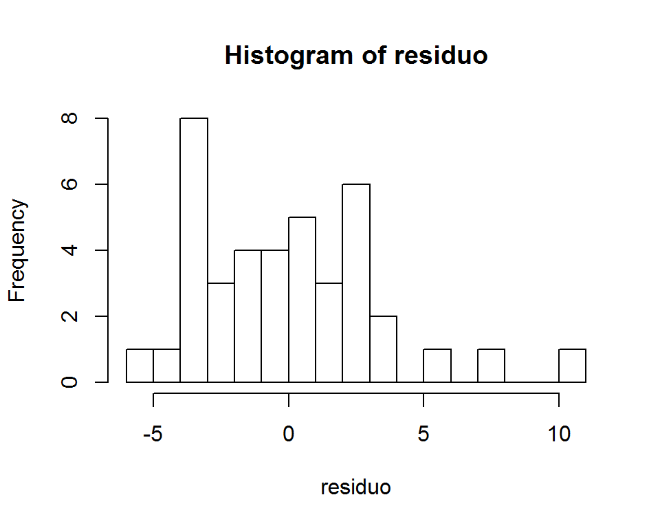

```r
hist(residuo,15)
```

```r
mean(residuo)
```

```
## [1] -2.310652e-16
```

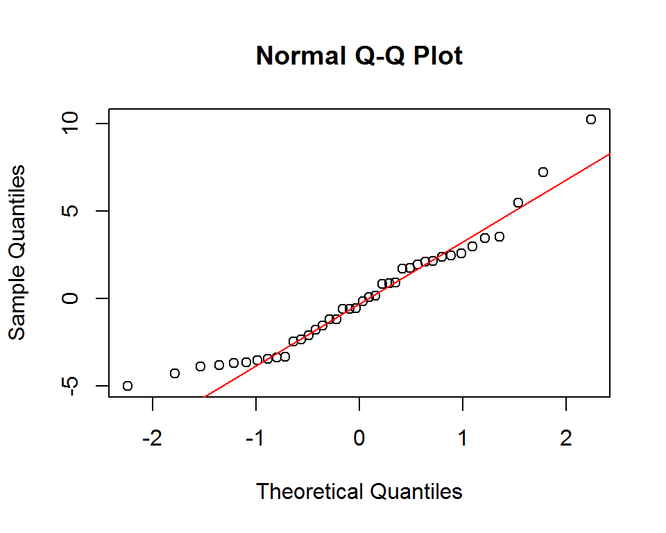

```r
qqnorm(residuo)
qqline(residuo,col="red")
```

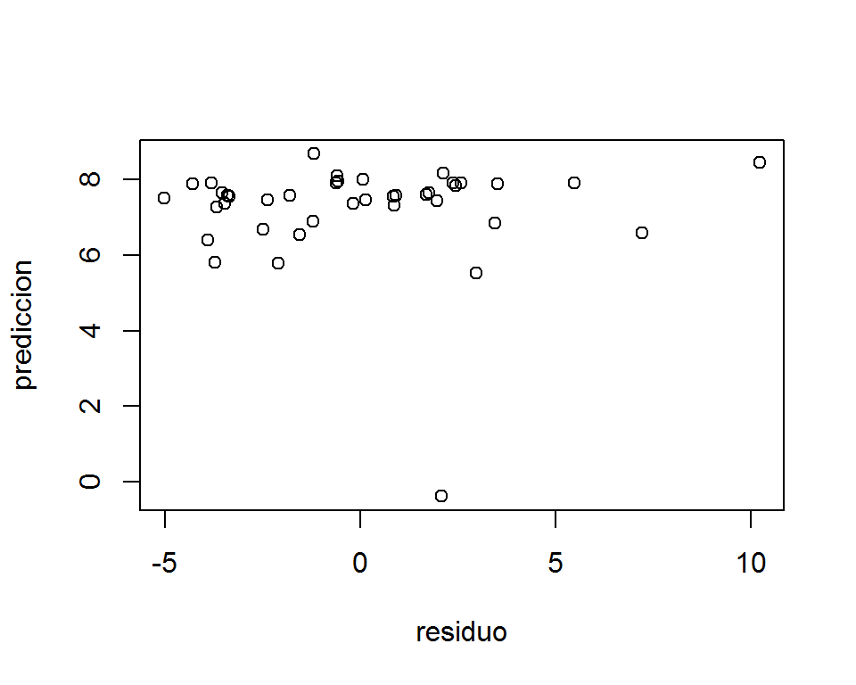

```r
plot(residuo,prediccion)
```